# ADA (week 8) Introduction to Stan: Self-practice & homework exercises

Vedant Shah

06/06/2020

# Instructions

- Use the file `08-exercises.Rmd`, solve the exercises marked as homework, and save the file with your student number and name.
- ‘Knit’ the document to produce a HTML file.
  - **include the other JS and CSS files that came with the ZIP file for this week in order to produce nicely looking Stan code in the HTML**
- **include the Stan code you write in the Rmarkdow (see example in exercise 1 below), even if you also include a seperate file to run that model from**
- Please do not suppress the code in the HTML-Output!
  - **do suppress the output of Stan by including the flag `results = "hide"` in the r chunk calling the `stan` function (see example in self-practice exercise 1)**
- Create a ZIP archive called “MATRIKELNR_Lastname_Firstname_ABDA_Week4.zip” containing:
  - an R Markdown file “MATRIKELNR_Lastname_Firstname_ABDA_Week4.Rmd”
  - a knitted HTML document “MATRIKELNR_Lastname_Firstname_ABDA_Week4.html”
  - **all of your Stan code files**
  - **the auxilliary JS and CSS files for syntax highlighting of Stan code**
- Upload the ZIP archive on Stud.IP in the homework folder before the deadline. You may upload as many times as you like before the deadline, only your final submission will count.

# Preliminaries

We need the package `rstan` installed and loaded for this week’s exercises.

We are going to set a seed, so that results from (pseudo-)random executions are repeatable.

```r
set.seed(1969)
```

# Motivation and learning goals

The main **learning goals** of this week’s practical part are:

- become familiar with Stan
- see a simple and some increasingly more difficult models implemented in Stan
- become comfortable with minor manipulations to Stan programs
- understand robust (regression) modeling

# Exercise 2 [HOMEWORK]: Outlier-robust inference

Using Stan, we have full control over our model. To see a case where this is useful, let’s consider **robust regression**. Remember that fitting a single Gaussian is like fitting an intercept-only linear regression model. So, what we do here applies to other regression models applied to metric data $y$, too. We are going to see that using a normal likelihood function makes our models very sensitive to outliers. To make them more robust against outliers we can change the likelihood function to using a [Student $t$ distribution](http://bois.caltech.edu/distribution_explorer/continuous/student_t.html), which has thicker tails.

```r
# flower height data (as before)
heights_A <- c(6.94, 11.77, 8.97, 12.2, 8.48,
               9.29, 13.03, 13.58, 7.63, 11.47,
               10.24, 8.99, 8.29, 10.01, 9.47,
               9.92, 6.83, 11.6, 10.29, 10.7,
               11, 8.68, 11.71, 10.09, 9.7)
# store the data in a vector with a better name & record its length
y <- heights_A
N <- length(y)
```

## 2.a Normal likelihood with outliers: what’s the problem?

Let’s add two rather extreme outliers to our data of flower heights:

```r
y_prime = c(y, 90,95)
```

We assemble the new data set:

```r
dataList <- list(y = y_prime, N = length(y_prime))
```

And then we use the Stan model from Exercise 1.b which also collects posterior predictives:

```r
# fit the model to the data (we use the same code as for Ex-1b)
fit_2a = stan(
  file = 'ADA-W08-Ex1b-single-Gaussian-prior-postpred.stan',
  data = dataList
)
```

If we inspect the summary statistics of fitted values, we see that, perhaps unsurprisingly but sadly, the inferred mean has changed in response to inclusion of the outliers.

```r
fit_2a
```

```
## Inference for Stan model: ADA-W08-Ex1b-single-Gaussian-prior-postpred.
## 4 chains, each with iter=2000; warmup=1000; thin=1;
## post-warmup draws per chain=1000, total post-warmup draws=4000.
##
##         mean se_mean    sd   2.5%    25%    50%    75%  97.5% n_eff Rhat
## mu     16.13    0.08  4.40   7.61  13.12  16.13  19.09  24.58  2683    1
## sigma  22.42    0.07  3.32  17.11  20.05  22.09  24.37  30.00  2331    1
## yrep   16.24    0.36 22.95 -28.33   1.45  15.60  31.27  62.83  3978    1
## lp__  -96.30    0.03  1.07 -99.13 -96.70 -95.98 -95.55 -95.25  1525    1
##
## Samples were drawn using NUTS(diag_e) at Mon Jun 15 23:59:44 2020.
## For each parameter, n_eff is a crude measure of effective sample size,
## and Rhat is the potential scale reduction factor on split chains (at
## convergence, Rhat=1).
```

That might seem okay, but things are not looking good for this model. We see this if we look at a simple visual posterior predictive check:

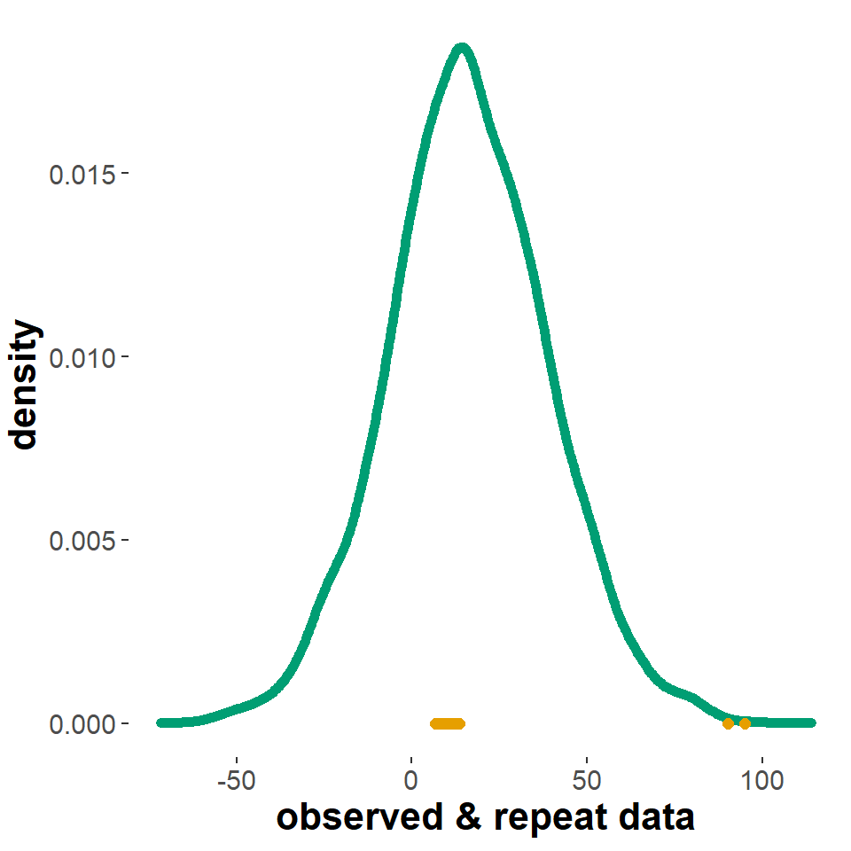

```r
# extract samples from 'stanfit' object in a tidy format
post_samples_2a <- tidybayes::tidy_draws(fit_2a)
# plot posterior predictive samples against the original data
post_samples_2a %>% ggplot(aes(x = yrep)) +
  geom_density(color = project_colors[3], size = 2) +
  geom_point(
    data = tibble(yrep = y_prime, y = 0),
    aes(y = y),
    color = project_colors[1],
    size = 2
  ) +
  xlab("observed & repeat data")
```

What’s the problem? Why does this plot show that the model is not a good model for this data?

```r
# The Outliers are affecting the posterior estimated distribution. The estimation is not representing the data properly. The estimation must be around the data and should be about to handle the outliers.
```